# Lending Tree

[figure not shown]

Data Analysis Lifecycle, Kernel Density Estimation (KDE), Principal Component Analysis (PCA)

Notebook setup here ...

## Situation

LendingTree is an online lending exchange that connects consumers with multiple lenders, banks, and credit partners who compete for business. Since being founded in 1998 LendingTree has facilitated more than 32 million loan requests.

## Business Model

### Influence Diagram

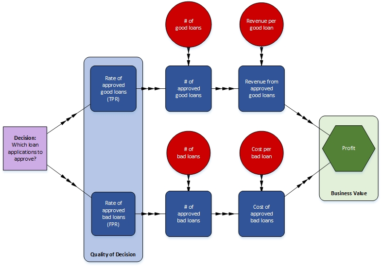

## Data

| observations | variables |
| --- | --- |
| 887379 | 74 |

**First few observations ...**

| id | member_id | loan_amnt | funded_amnt | funded_amnt_inv | term | int_rate | installment | grade | sub_grade | emp_title | emp_length | home_ownership | annual_inc | verification_status | issue_d | loan_status | pymnt_plan | url | desc | purpose | title | zip_code | addr_state | dti | delinq_2yrs | earliest_cr_line | inq_last_6mths | mths_since_last_delinq | mths_since_last_record | … |
| --- | --- | --- | --- | --- | --- | --- | --- | --- | --- | --- | --- | --- | --- | --- | --- | --- | --- | --- | --- | --- | --- | --- | --- | --- | --- | --- | --- | --- | --- | --- |
| 1077501 | 1296599 | 5000 | 5000 | 4975 | 36 months | 10.65 | 162.87 | B | B2 |  | 10+ years | RENT | 24000 | Verified | Dec-2011 | Fully Paid | n | https://www.lendingclub.com/browse/loanDetail.action?loan_id=1077501 | Borrower added on 12/22/11 > I need to upgrade my business technologies.<br> | credit_card | Computer | 860xx | AZ | 27.65 | 0 | Jan-1985 | 1 | NA | NA | … |
| 1077430 | 1314167 | 2500 | 2500 | 2500 | 60 months | 15.27 | 59.83 | C | C4 | Ryder | < 1 year | RENT | 30000 | Source Verified | Dec-2011 | Charged Off | n | https://www.lendingclub.com/browse/loanDetail.action?loan_id=1077430 | Borrower added on 12/22/11 > I plan to use this money to finance the motorcycle i am looking at. I plan to have it paid off as soon as possible/when i sell my old bike. I only need this money because … | car | bike | 309xx | GA | 1.00 | 0 | Apr-1999 | 5 | NA | NA | … |
| 1077175 | 1313524 | 2400 | 2400 | 2400 | 36 months | 15.96 | 84.33 | C | C5 |  | 10+ years | RENT | 12252 | Not Verified | Dec-2011 | Fully Paid | n | https://www.lendingclub.com/browse/loanDetail.action?loan_id=1077175 |  | small_business | real estate business | 606xx | IL | 8.72 | 0 | Nov-2001 | 2 | NA | NA | … |

## Prepare Data

### Focus Analysis on Data Subset

Note which loans are inactive. Note which inactive loans were or were not paid back.

| all labels |
| --- |
| Fully Paid |
| Charged Off |
| Current |
| Default |
| Late (31-120 days) |
| In Grace Period |
| Late (16-30 days) |
| Does not meet the credit policy. Status:Fully Paid |
| Does not meet the credit policy. Status:Charged Off |
| Issued |

| good_labels |
| --- |
| Fully Paid |
| Does not meet the credit policy. Status:Fully Paid |

| bad_labels |
| --- |
| Default |
| Charged Off |
| Does not meet the credit policy. Status:Charged Off |

**observation count**

| good | bad | inactive |
| --- | --- | --- |
| 209711 | 47228 | 256939 |

### Focus Analysis on Convenient Variables

Which variables are not IDs?

1. 3

2. 4

3. 5

4. 6

5. 7

6. 8

7. 9

8. 10

9. 11

10. 12

11. 13

12. 14

13. 15

14. 16

15. 17

16. 18

17. 19

18. 20

19. 21

20. 22

21. 23

22. 24

23. 25

24. 26

25. 27

26. 28

27. 29

28. 30

29. 31

30. 32

31. 33

32. 34

33. 35

34. 36

35. 37

36. 38

37. 39

38. 40

39. 41

40. 42

41. 43

42. 44

43. 45

44. 46

45. 47

46. 48

47. 49

48. 50

49. 51

50. 52

51. 53

52. 54

53. 55

54. 56

55. 57

56. 58

57. 59

58. 60

59. 61

60. 62

61. 63

62. 64

63. 65

64. 66

65. 67

66. 68

67. 69

68. 70

69. 71

70. 72

71. 73

72. 74

Which variables are numeric?

1. 1

2. 2

3. 3

4. 4

5. 5

6. 7

7. 8

8. 14

9. 25

10. 26

11. 28

12. 29

13. 30

14. 31

15. 32

16. 33

17. 34

18. 35

19. 37

20. 38

21. 39

22. 40

23. 41

24. 42

25. 43

26. 44

27. 45

28. 47

29. 50

30. 51

31. 52

32. 54

33. 55

34. 57

35. 58

36. 59

37. 60

38. 61

39. 62

40. 63

41. 64

42. 65

43. 66

44. 67

45. 68

46. 69

47. 70

48. 71

49. 72

50. 73

51. 74

Which variables are complete (no missing data)?

1. 1

2. 2

3. 3

4. 4

5. 5

6. 6

7. 7

8. 8

9. 9

10. 10

11. 11

12. 12

13. 13

14. 15

15. 16

16. 17

17. 18

18. 19

19. 20

20. 21

21. 22

22. 23

23. 24

24. 25

25. 27

26. 33

27. 36

28. 37

29. 38

30. 39

31. 40

32. 41

33. 42

34. 43

35. 44

36. 45

37. 46

38. 47

39. 48

40. 49

41. 52

42. 53

43. 56

Which variables have at least some variation (distribution of more than one value)?

1. 1

2. 2

3. 3

4. 4

5. 5

6. 6

7. 7

8. 8

9. 9

10. 10

11. 11

12. 12

13. 13

14. 14

15. 15

16. 16

17. 17

18. 18

19. 19

20. 20

21. 21

22. 22

23. 23

24. 24

25. 25

26. 26

27. 27

28. 28

29. 29

30. 30

31. 31

32. 32

33. 33

34. 34

35. 35

36. 36

37. 37

38. 38

39. 39

40. 40

41. 41

42. 42

43. 43

44. 44

45. 45

46. 46

47. 47

48. 48

49. 49

50. 50

51. 51

52. 53

53. 54

54. 55

55. 56

56. 57

57. 58

58. 59

59. 60

60. 61

61. 62

62. 63

63. 64

64. 65

65. 66

66. 67

67. 68

68. 69

69. 70

70. 71

71. 72

72. 73

73. 74

These are the convenient variables:

1. 3

2. 4

3. 5

4. 7

5. 8

6. 25

7. 33

8. 37

9. 38

10. 39

11. 40

12. 41

13. 42

14. 43

15. 44

16. 45

17. 47

### Prepared Data

| observations | variables |
| --- | --- |
| 256939 | 17 |

**First few good loan observations ...**

| loan_amnt | funded_amnt | funded_amnt_inv | int_rate | installment | dti | revol_bal | out_prncp | out_prncp_inv | total_pymnt | total_pymnt_inv | total_rec_prncp | total_rec_int | total_rec_late_fee | recoveries | collection_recovery_fee | last_pymnt_amnt |
| --- | --- | --- | --- | --- | --- | --- | --- | --- | --- | --- | --- | --- | --- | --- | --- | --- |
| 5000 | 5000 | 4975 | 10.65 | 162.87 | 27.65 | 13648 | 0 | 0 | 5861.071 | 5831.78 | 5000 | 861.07 | 0.00 | 0 | 0 | 171.62 |
| 2400 | 2400 | 2400 | 15.96 | 84.33 | 8.72 | 2956 | 0 | 0 | 3003.654 | 3003.65 | 2400 | 603.65 | 0.00 | 0 | 0 | 649.91 |
| 10000 | 10000 | 10000 | 13.49 | 339.31 | 20.00 | 5598 | 0 | 0 | 12226.302 | 12226.30 | 10000 | 2209.33 | 16.97 | 0 | 0 | 357.48 |
| 5000 | 5000 | 5000 | 7.90 | 156.46 | 11.20 | 7963 | 0 | 0 | 5631.378 | 5631.38 | 5000 | 631.38 | 0.00 | 0 | 0 | 161.03 |
| 3000 | 3000 | 3000 | 18.64 | 109.43 | 5.35 | 8221 | 0 | 0 | 3938.144 | 3938.14 | 3000 | 938.14 | 0.00 | 0 | 0 | 111.34 |
| 6500 | 6500 | 6500 | 14.65 | 153.45 | 16.12 | 4032 | 0 | 0 | 7677.520 | 7677.52 | 6500 | 1177.52 | 0.00 | 0 | 0 | 1655.54 |

**First few bad loan observations ...**

| loan_amnt | funded_amnt | funded_amnt_inv | int_rate | installment | dti | revol_bal | out_prncp | out_prncp_inv | total_pymnt | total_pymnt_inv | total_rec_prncp | total_rec_int | total_rec_late_fee | recoveries | collection_recovery_fee | last_pymnt_amnt |
| --- | --- | --- | --- | --- | --- | --- | --- | --- | --- | --- | --- | --- | --- | --- | --- | --- |
| 2500 | 2500 | 2500 | 15.27 | 59.83 | 1.00 | 1687 | 0 | 0 | 1008.71 | 1008.71 | 456.46 | 435.17 | 0 | 117.08 | 1.1100 | 119.66 |
| 5600 | 5600 | 5600 | 21.28 | 152.39 | 5.55 | 5210 | 0 | 0 | 646.02 | 646.02 | 162.02 | 294.94 | 0 | 189.06 | 2.0900 | 152.39 |
| 5375 | 5375 | 5350 | 12.69 | 121.45 | 18.08 | 9279 | 0 | 0 | 1476.19 | 1469.34 | 673.48 | 533.42 | 0 | 269.29 | 2.5200 | 121.45 |
| 9000 | 9000 | 9000 | 13.49 | 305.38 | 10.08 | 10452 | 0 | 0 | 2270.70 | 2270.70 | 1256.14 | 570.26 | 0 | 444.30 | 4.1600 | 305.38 |
| 10000 | 10000 | 10000 | 10.65 | 325.74 | 7.06 | 11997 | 0 | 0 | 7471.99 | 7471.99 | 5433.47 | 1393.42 | 0 | 645.10 | 6.3145 | 325.74 |
| 21000 | 21000 | 21000 | 12.42 | 701.73 | 13.22 | 32135 | 0 | 0 | 14025.40 | 14025.40 | 10694.96 | 3330.44 | 0 | 0.00 | 0.0000 | 701.73 |

## Explore Data

### Scree Plot of Variables

| variable | sdev | variance | cum_variance | relative_variance | cum_relative_variance |
| --- | --- | --- | --- | --- | --- |
| loan_amnt | 8128.811481 | 66077576.08731 | 66077576 | 0.07372040774082 | 0.07372041 |
| funded_amnt | 8106.456843 | 65714642.55324 | 131792219 | 0.07331549567082 | 0.14703590 |
| funded_amnt_inv | 8141.904114 | 66290602.60264 | 198082821 | 0.07395807386751 | 0.22099398 |
| int_rate | 4.389704 | 19.26950 | 198082841 | 0.00000002149830 | 0.22099400 |
| installment | 244.878760 | 59965.60734 | 198142806 | 0.00006690150101 | 0.22106090 |
| dti | 7.793541 | 60.73928 | 198142867 | 0.00000006776466 | 0.22106097 |
| revol_bal | 19708.797999 | 388436718.57730 | 586579585 | 0.43336506831285 | 0.65442604 |
| out_prncp | 951.034000 | 904465.66837 | 587484051 | 0.00100908026305 | 0.65543512 |
| out_prncp_inv | 950.770737 | 903964.99381 | 588388016 | 0.00100852167820 | 0.65644364 |
| total_pymnt | 9474.816669 | 89772150.91713 | 678160167 | 0.10015560438592 | 0.75659924 |
| total_pymnt_inv | 9487.339561 | 90009611.95400 | 768169779 | 0.10042053124155 | 0.85701977 |
| total_rec_prncp | 8331.138609 | 69407870.52591 | 837577649 | 0.07743589911396 | 0.93445567 |
| total_rec_int | 2063.549500 | 4258236.53795 | 841835886 | 0.00475076345748 | 0.93920644 |
| total_rec_late_fee | 5.569508 | 31.01942 | 841835917 | 0.00000003460727 | 0.93920647 |
| recoveries | 749.550714 | 561826.27299 | 842397743 | 0.00062680964371 | 0.93983328 |
| collection_recovery_fee | 116.448713 | 13560.30281 | 842411304 | 0.00001512874883 | 0.93984841 |
| last_pymnt_amnt | 7342.716238 | 53915481.75208 | 896326785 | 0.06015159050408 | 1.00000000 |

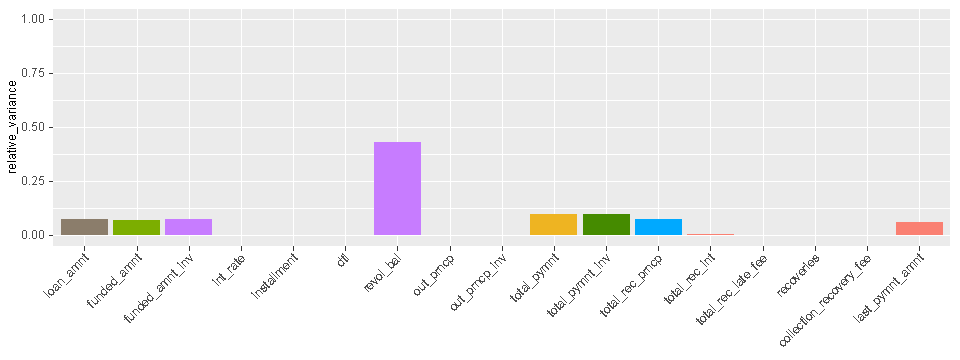

### 1D Scatter Plots of 2 Variables

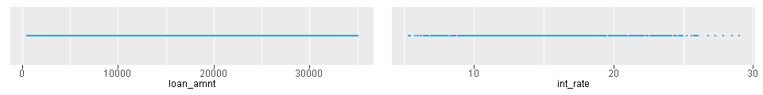

### Probability Density Functions of 2 Variables

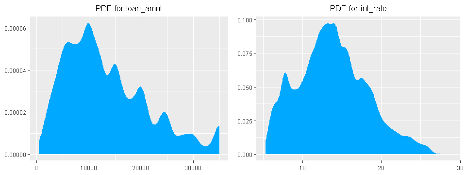

### 2D Scatter Plot of 2 Variables

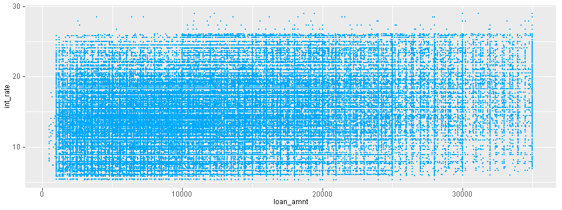

## Try to Distiguish Observations by Loan Class

### Probabilities of Variable Values in Certain Ranges

| variable | probability | range_low | range_high |
| --- | --- | --- | --- |
| loan_amnt | 0.7360615 | 0 | 18000 |
| int_rate | 0.7026378 | 10 | 20 |

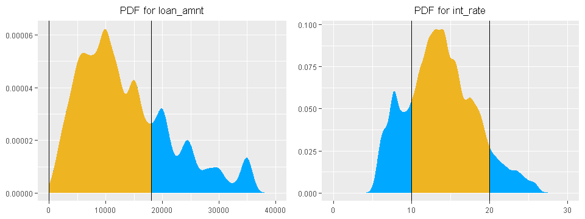

### Probabilities of Variable Values in Certain Ranges: Good Loans

| variable | probability | range_low | range_high |
| --- | --- | --- | --- |
| loan_amnt | 0.7458814 | 0 | 18000 |
| int_rate | 0.6938446 | 10 | 20 |

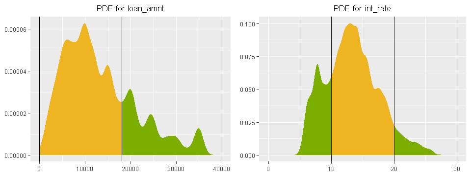

### Probabilities of Variable Values in Certain Ranges: Bad Loans

| variable | probability | range_low | range_high |
| --- | --- | --- | --- |
| loan_amnt | 0.6924573 | 0 | 18000 |
| int_rate | 0.7416823 | 10 | 20 |

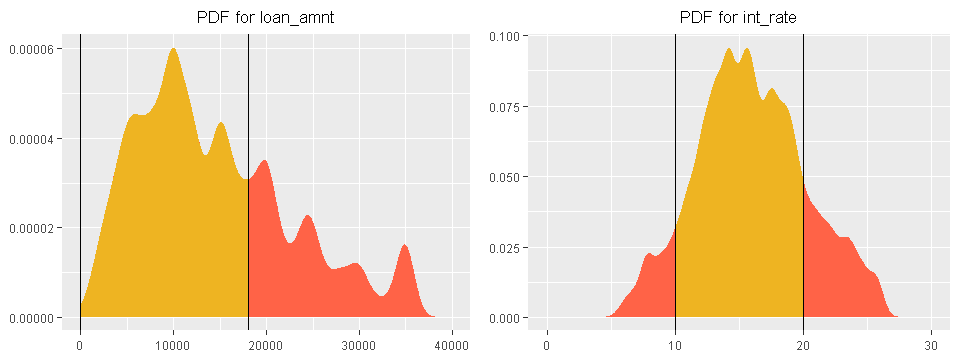

### 2D Scatter Plot of 2 Variables + Loan Class

Note that distinguishing characteristics are obscured.

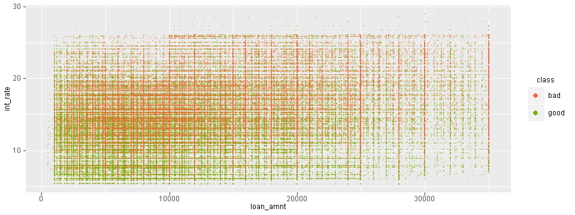

## Further Prepare Data: Principal Component Analysis

### Data Represented as Principal Components

| observations | variables |
| --- | --- |
| 256939 | 17 |

**First few observations ...**

| PC1 | PC2 | PC3 | PC4 | PC5 | PC6 | PC7 | PC8 | PC9 | PC10 | PC11 | PC12 | PC13 | PC14 | PC15 | PC16 | PC17 |
| --- | --- | --- | --- | --- | --- | --- | --- | --- | --- | --- | --- | --- | --- | --- | --- | --- |
| -2.6728263 | -0.1465467 | 0.0450934 | 0.8419750 | 0.8696164 | -0.3897855 | -0.5294172 | 0.7748944 | 0.4203098 | -0.0536682 | -0.0249489 | -0.0257247 | 0.0059798 | 0.0023199 | 0.0012540 | -0.0000036 | -0.0000001 |
| -3.4690408 | -0.1686156 | -0.0128454 | -0.0778179 | -0.7831999 | 0.5919857 | 0.6007657 | -0.5759597 | 0.1728710 | 0.0679205 | -0.0906673 | -0.0424623 | 0.0172338 | 0.0015672 | 0.0006855 | 0.0000004 | -0.0000003 |
| -0.9233908 | 0.3227803 | -0.1853512 | 0.6327526 | -1.8526851 | -2.1063312 | -0.8736050 | 0.3179850 | 0.3868079 | 0.1452196 | -0.3080882 | -0.0586827 | 0.0314312 | -0.0011145 | 0.0019065 | -0.0000014 | -0.0000002 |
| -2.8601307 | -0.5530504 | 0.1121233 | -0.9970486 | 0.0589515 | -0.2607079 | 0.2205148 | 0.4953472 | 0.2642117 | -0.1202111 | 0.0950570 | -0.0187472 | 0.0277040 | 0.0038231 | 0.0011372 | -0.0000006 | 0.0000002 |
| -3.1631177 | -0.0416238 | -0.0576907 | 0.0428298 | -1.0869344 | 0.7352626 | 1.1560934 | -0.9323186 | 0.1285576 | 0.2022035 | -0.2282229 | -0.0714973 | 0.0190179 | 0.0015922 | 0.0008001 | 0.0000009 | -0.0000003 |
| -2.2223630 | -0.1828012 | 0.0160060 | 0.2814129 | -0.3269076 | 0.3858523 | 0.0359717 | 0.0186176 | 0.2733875 | 0.0445881 | -0.1191158 | -0.2463197 | -0.0109397 | 0.0094793 | 0.0034006 | -0.0000021 | 0.0000000 |

### Qualitative Interpretation of Principal Components.

Here, each column lists variable names sorted by weight applied to the principal component.

| PC1 | PC2 | PC3 | PC4 | PC5 | PC6 | PC7 | PC8 | PC9 | PC10 | PC11 | PC12 | PC13 | PC14 | PC15 | PC16 | PC17 |
| --- | --- | --- | --- | --- | --- | --- | --- | --- | --- | --- | --- | --- | --- | --- | --- | --- |
| funded_amnt | recoveries | out_prncp | dti | total_rec_late_fee | total_rec_late_fee | revol_bal | last_pymnt_amnt | total_rec_int | recoveries | total_rec_int | installment | funded_amnt_inv | loan_amnt | funded_amnt | out_prncp_inv | total_pymnt |
| loan_amnt | collection_recovery_fee | out_prncp_inv | int_rate | revol_bal | revol_bal | dti | int_rate | collection_recovery_fee | collection_recovery_fee | last_pymnt_amnt | funded_amnt_inv | total_pymnt_inv | funded_amnt | total_pymnt_inv | out_prncp | total_rec_prncp |
| funded_amnt_inv | out_prncp | recoveries | collection_recovery_fee | dti | int_rate | last_pymnt_amnt | total_rec_int | installment | last_pymnt_amnt | recoveries | loan_amnt | loan_amnt | total_pymnt_inv | funded_amnt_inv | funded_amnt | total_rec_int |
| total_pymnt | out_prncp_inv | collection_recovery_fee | total_rec_int | int_rate | dti | total_rec_int | dti | total_pymnt | total_rec_int | total_rec_prncp | funded_amnt | funded_amnt | funded_amnt_inv | total_rec_prncp | total_pymnt_inv | recoveries |
| total_pymnt_inv | int_rate | int_rate | recoveries | total_rec_int | last_pymnt_amnt | total_rec_late_fee | revol_bal | funded_amnt | installment | collection_recovery_fee | last_pymnt_amnt | total_rec_prncp | total_rec_prncp | total_pymnt | funded_amnt_inv | total_rec_late_fee |
| installment | total_rec_prncp | total_rec_late_fee | revol_bal | collection_recovery_fee | total_rec_int | int_rate | total_rec_late_fee | funded_amnt_inv | int_rate | total_pymnt_inv | total_rec_int | total_pymnt | total_pymnt | loan_amnt | total_rec_prncp | funded_amnt |
| total_rec_prncp | last_pymnt_amnt | last_pymnt_amnt | total_rec_prncp | last_pymnt_amnt | recoveries | collection_recovery_fee | collection_recovery_fee | total_pymnt_inv | total_rec_prncp | total_pymnt | total_pymnt_inv | installment | total_rec_int | total_rec_int | total_pymnt | loan_amnt |
| total_rec_int | total_rec_late_fee | total_rec_prncp | total_rec_late_fee | recoveries | collection_recovery_fee | total_rec_prncp | installment | loan_amnt | total_pymnt | int_rate | total_rec_prncp | total_rec_int | installment | recoveries | total_rec_int | out_prncp_inv |
| last_pymnt_amnt | total_rec_int | total_rec_int | out_prncp_inv | total_pymnt | installment | recoveries | loan_amnt | total_rec_prncp | total_pymnt_inv | loan_amnt | int_rate | recoveries | recoveries | installment | installment | out_prncp |
| revol_bal | total_pymnt_inv | total_pymnt_inv | out_prncp | total_pymnt_inv | total_pymnt_inv | total_pymnt_inv | funded_amnt | last_pymnt_amnt | dti | funded_amnt | recoveries | last_pymnt_amnt | last_pymnt_amnt | last_pymnt_amnt | loan_amnt | total_pymnt_inv |
| int_rate | total_pymnt | installment | loan_amnt | total_rec_prncp | total_pymnt | funded_amnt_inv | funded_amnt_inv | int_rate | total_rec_late_fee | funded_amnt_inv | total_pymnt | int_rate | revol_bal | revol_bal | recoveries | funded_amnt_inv |
| recoveries | dti | total_pymnt | funded_amnt | funded_amnt_inv | loan_amnt | out_prncp_inv | recoveries | revol_bal | out_prncp | installment | collection_recovery_fee | dti | dti | total_rec_late_fee | dti | installment |
| dti | funded_amnt | loan_amnt | installment | out_prncp | funded_amnt | out_prncp | total_pymnt | dti | out_prncp_inv | out_prncp_inv | total_rec_late_fee | revol_bal | out_prncp | collection_recovery_fee | last_pymnt_amnt | last_pymnt_amnt |
| collection_recovery_fee | loan_amnt | funded_amnt | funded_amnt_inv | out_prncp_inv | out_prncp_inv | total_pymnt | total_pymnt_inv | out_prncp | funded_amnt | out_prncp | out_prncp_inv | collection_recovery_fee | out_prncp_inv | out_prncp | revol_bal | collection_recovery_fee |
| total_rec_late_fee | funded_amnt_inv | funded_amnt_inv | last_pymnt_amnt | funded_amnt | out_prncp | funded_amnt | total_rec_prncp | out_prncp_inv | funded_amnt_inv | total_rec_late_fee | out_prncp | total_rec_late_fee | collection_recovery_fee | dti | int_rate | revol_bal |
| out_prncp_inv | installment | dti | total_pymnt | loan_amnt | funded_amnt_inv | loan_amnt | out_prncp_inv | total_rec_late_fee | revol_bal | dti | revol_bal | out_prncp | total_rec_late_fee | int_rate | total_rec_late_fee | int_rate |
| out_prncp | revol_bal | revol_bal | total_pymnt_inv | installment | total_rec_prncp | installment | out_prncp | recoveries | loan_amnt | revol_bal | dti | out_prncp_inv | int_rate | out_prncp_inv | collection_recovery_fee | dti |

### Scree Plot of Principal Components

| variable | sdev | variance | cum_variance | relative_variance | cum_relative_variance |
| --- | --- | --- | --- | --- | --- |
| PC1 | 2.7173098262308 | 7.38377269173050354567 | 7.383773 | 4.343396e-01 | 0.4343396 |
| PC2 | 1.4721417710771 | 2.16720139414998724803 | 9.550974 | 1.274824e-01 | 0.5618220 |
| PC3 | 1.4095611181014 | 1.98686254566316522485 | 11.537837 | 1.168743e-01 | 0.6786963 |
| PC4 | 1.0740640204197 | 1.15361351996019578792 | 12.691450 | 6.785962e-02 | 0.7465559 |
| PC5 | 1.0252282001400 | 1.05109286236220822452 | 13.742543 | 6.182899e-02 | 0.8083849 |
| PC6 | 0.9839736782539 | 0.96820419949641245427 | 14.710747 | 5.695319e-02 | 0.8653381 |
| PC7 | 0.8726487333024 | 0.76151581173426796667 | 15.472263 | 4.479505e-02 | 0.9101331 |
| PC8 | 0.8007443563781 | 0.64119152427136827388 | 16.113455 | 3.771715e-02 | 0.9478503 |
| PC9 | 0.6959904525408 | 0.48440271002792323340 | 16.597857 | 2.849428e-02 | 0.9763445 |
| PC10 | 0.4282900978415 | 0.18343240790906042981 | 16.781290 | 1.079014e-02 | 0.9871347 |
| PC11 | 0.3838905536732 | 0.14737195719954723772 | 16.928662 | 8.668939e-03 | 0.9958036 |
| PC12 | 0.2264373204043 | 0.05127386007188090150 | 16.979935 | 3.016109e-03 | 0.9988197 |
| PC13 | 0.1296854523344 | 0.01681831654718120642 | 16.996754 | 9.893127e-04 | 0.9998090 |
| PC14 | 0.0516619051102 | 0.00266895243961772855 | 16.999423 | 1.569972e-04 | 0.9999660 |
| PC15 | 0.0240075314565 | 0.00057636156663439626 | 16.999999 | 3.390362e-05 | 0.9999999 |
| PC16 | 0.0009406752990 | 0.00000088487001808063 | 17.000000 | 5.205118e-08 | 1.0000000 |
| PC17 | 0.0000001309906 | 0.00000000000001715855 | 17.000000 | 1.009326e-15 | 1.0000000 |

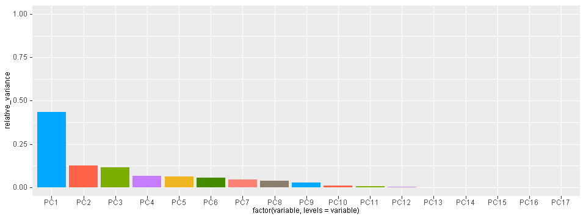

## Try to Distiguish Transformed Observations by Loan Class

### Probabilities of Principal Component Values in Certain Ranges: Good Loans

| variable | probability | range_low | range_high |
| --- | --- | --- | --- |
| PC1 | 0.6844254 | -5.0 | 1 |
| PC2 | 0.6905644 | -0.8 | 0 |

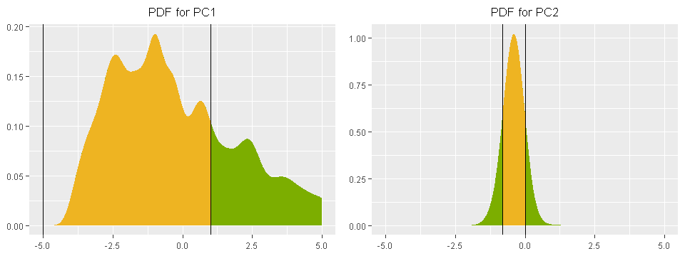

| variable | probability | range_low | range_high |
| --- | --- | --- | --- |
| PC1 | 0.5677632 | -5.0 | 0 |
| PC2 | 0.3979042 | -0.3 | 2 |

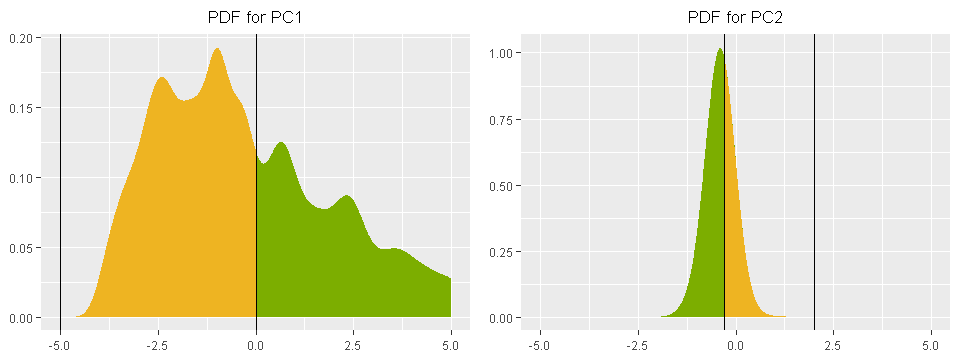

| variable | probability | range_low | range_high |
| --- | --- | --- | --- |
| PC1 | 0.81221398 | -5.0 | 1 |
| PC2 | 0.09640703 | -0.8 | 0 |

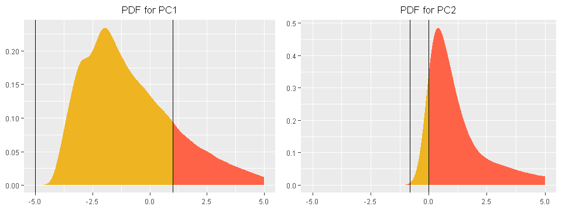

| variable | probability | range_low | range_high |
| --- | --- | --- | --- |
| PC1 | 0.6979371 | -5.0 | 0 |
| PC2 | 0.7164473 | -0.3 | 2 |

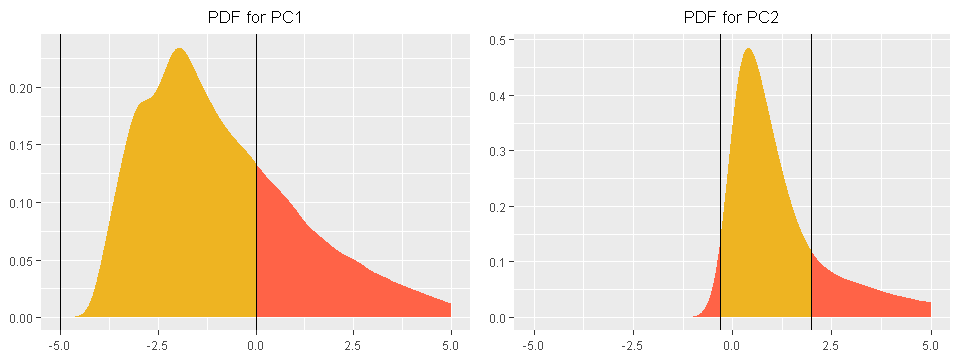

### 2D Scatter Plot of 2 Principal Components + Loan Class

Note that distinguishing characteristics are revealed.

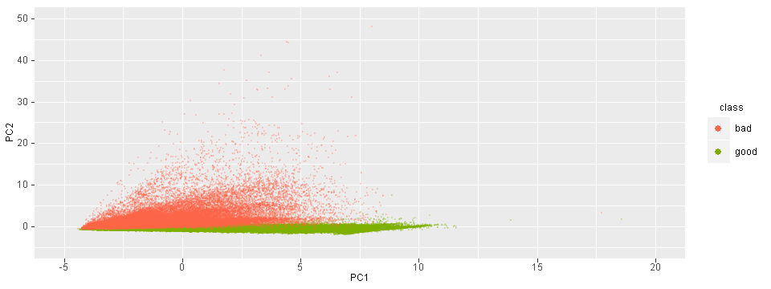

## Predictive Model

### Homogeneous Spaces

#### Convex Hulls Around Observations by Loan Class

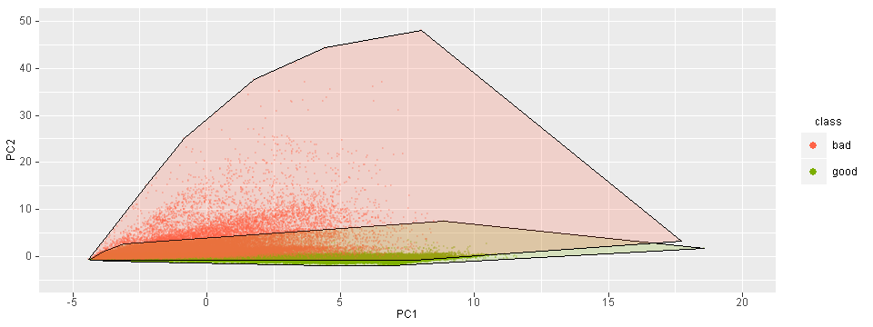

#### Homogeneous Spaces by Loan Class

A predictive model with high certainty ...

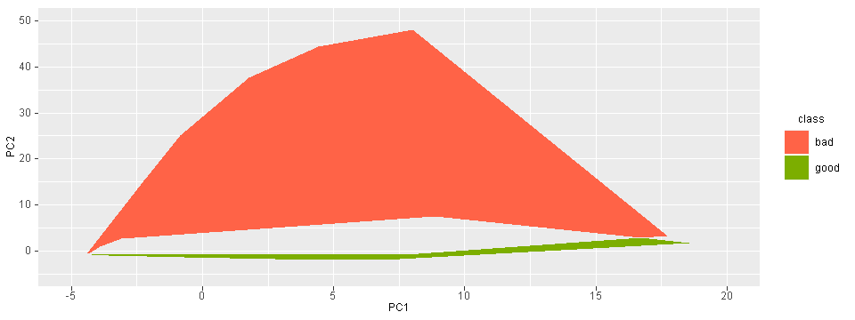

### Non-Homogeneous Space

#### Probabilities of Observations in Certain Ranges: Good Loans

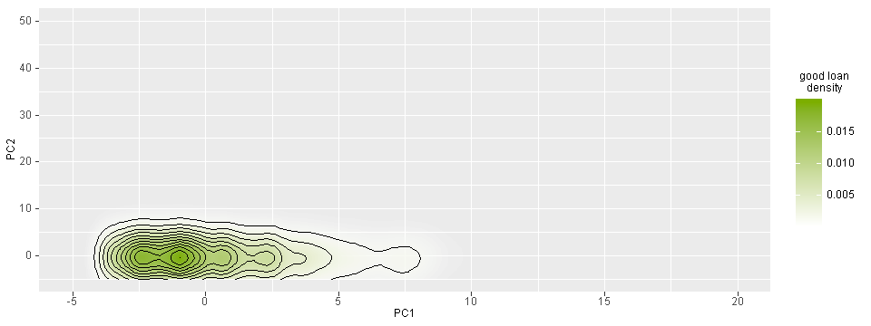

#### Probabilities of Observations in Certain Ranges: Bad Loans

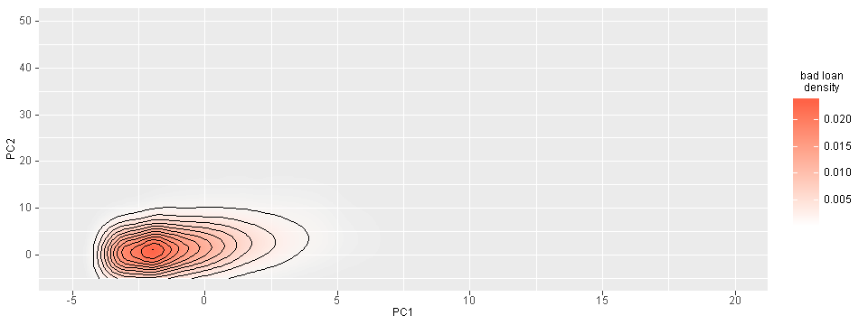

#### Hide the 5% Most Remote Observations

This will reduce overlap of convex hulls.

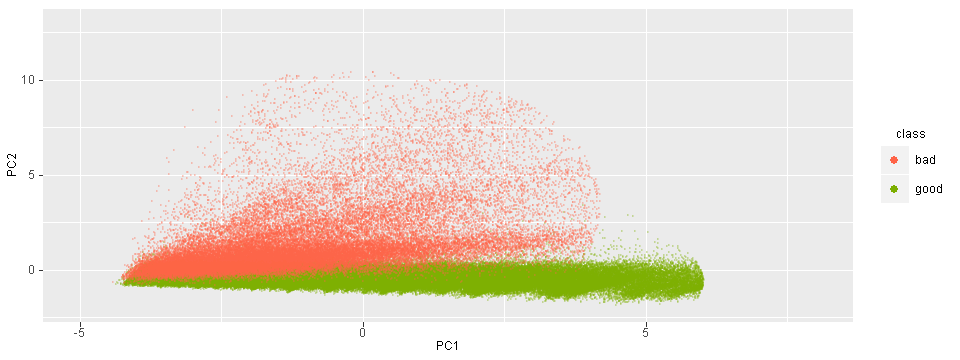

#### Convex Hulls Around Observations by Loan Class

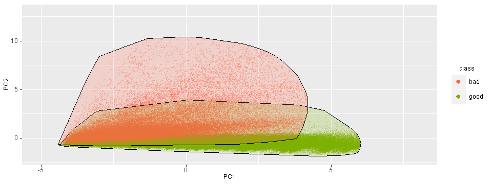

#### Homogeneous Spaces by Loan Class

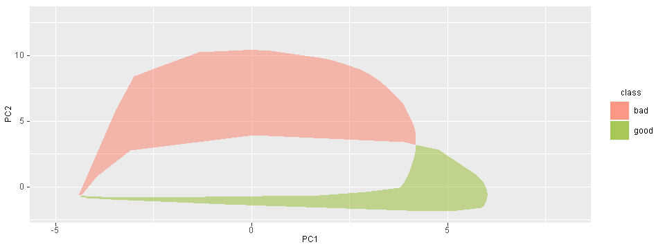

#### Homogenous Spaces by Loan Class - account for high certainty

A predictive model with moderate certainty ...

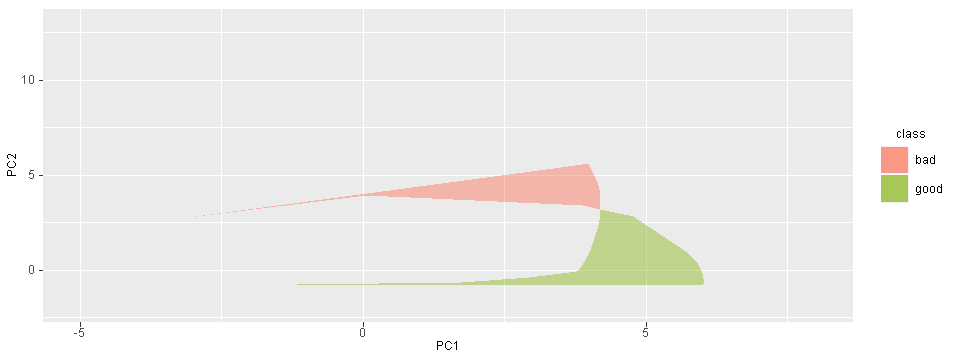

### Model Form & Parameterization

A predictive model with high and moderate certainties ...

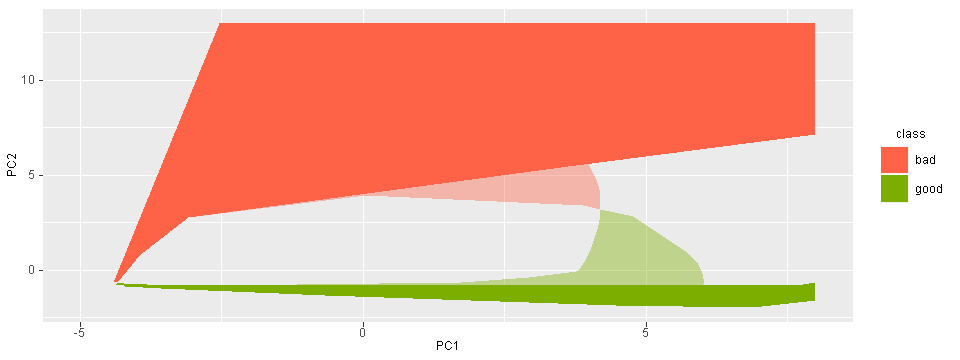

#### Hyper-Parameters

This model's parameters were determined by 1 hyper-parameter:

1. Fraction of observations to hide

| fraction of observations to hide |
| --- |
| 0.05 |

#### Parameters

This model is defined by 4 parameters:

1. Polygon vertices for high certainty good loans
2. Polygon vertices for high certainty bad loans
3. Polygon vertices for moderate certainty good loans
4. Polygon vertices for moderate certainty bad loans

**If new observation is within this space, then predict it's a good loan with high certainty:**

| PC1 | 6.899866 | 18.586382 | 16.715751 | 7.7807580 | -2.6168771 | -3.822216 | -4.2185936 | -4.3480485 | -4.3566855 | -4.2202007 | -4.1992759 | -3.5756162 | -0.6746178 | 4.469709 | 6.829755 |
| --- | --- | --- | --- | --- | --- | --- | --- | --- | --- | --- | --- | --- | --- | --- | --- |
| PC2 | -1.926050 | 1.750368 | 2.860872 | -0.7392996 | -0.7838926 | -0.728736 | -0.7044975 | -0.6523005 | -0.7143197 | -0.8148443 | -0.8198754 | -0.9286186 | -1.2927344 | -1.828825 | -1.933555 |

**If new observation is within this space, then predict it's a bad loan with high certainty:**

| PC1 | -4.3473015 | -4.0007488 | -3.892890 | -3.088704 | 3.622604 | 8.874498 | 16.715751 | 17.727861 | 8.014715 | 4.398551 | 1.781564 | -0.8352832 | -2.25130 | -4.4103049 | -4.3480485 |
| --- | --- | --- | --- | --- | --- | --- | --- | --- | --- | --- | --- | --- | --- | --- | --- |
| PC2 | -0.6469363 | 0.5945983 | 0.929579 | 2.797726 | 5.477395 | 7.515850 | 2.860872 | 3.268681 | 48.066636 | 44.386622 | 37.548973 | 25.1209963 | 15.15825 | -0.6271984 | -0.6523005 |

**If new observation is within this space, then predict it's a good loan with moderate certainty:**

| PC1 | 6.0160762 | 6.0162108 | 6.0181859 | 6.0181234 | 6.0163428 | 5.997049 | 5.973674 | 5.8946978 | 5.8757471 | 5.8316743 | 5.7431932 | 5.571823 | 4.779064 | 4.190689 | 4.193672 | 4.158253 | 4.037152 | 3.9172251 | 3.8121364 | 3.7593975 | 2.9381278 | 1.7298783 | -2.6168771 |
| --- | --- | --- | --- | --- | --- | --- | --- | --- | --- | --- | --- | --- | --- | --- | --- | --- | --- | --- | --- | --- | --- | --- | --- |
| PC2 | -0.7468679 | -0.7371088 | -0.5459777 | -0.4978903 | -0.4431477 | -0.183928 | 0.007853 | 0.4024227 | 0.4768712 | 0.6163381 | 0.8787068 | 1.256474 | 2.836647 | 3.225395 | 2.955126 | 2.384765 | 1.222216 | 0.5169519 | 0.0670099 | -0.0747394 | -0.3552457 | -0.6380095 | -0.7838926 |

| PC1 | 0.0476121 | 3.883017 | 4.190689 | 4.181962 | 4.164292 | 4.115338 | 3.980506 | 3.622604 | -3.088703 |
| --- | --- | --- | --- | --- | --- | --- | --- | --- | --- |
| PC2 | 3.9295622 | 3.428678 | 3.225395 | 4.016120 | 4.246145 | 4.808163 | 5.616310 | 5.477395 | 2.797727 |

## Prediction

Some new observations ...

| id | member_id | loan_amnt | funded_amnt | funded_amnt_inv | term | int_rate | installment | grade | sub_grade | emp_title | emp_length | home_ownership | annual_inc | verification_status | issue_d | loan_status | pymnt_plan | url | desc | purpose | title | zip_code | addr_state | dti | delinq_2yrs | earliest_cr_line | inq_last_6mths | mths_since_last_delinq | mths_since_last_record | … |
| --- | --- | --- | --- | --- | --- | --- | --- | --- | --- | --- | --- | --- | --- | --- | --- | --- | --- | --- | --- | --- | --- | --- | --- | --- | --- | --- | --- | --- | --- | --- |
| 1028052 | 1257431 | 16800 | 16800 | 16800 | 36 months | 6.03 | 511.32 | A | A1 | BNY Mellon | 5 years | MORTGAGE | 75000 | Not Verified | Nov-2011 | Fully Paid | n | https://www.lendingclub.com/browse/loanDetail.action?loan_id=1028052 |  | debt_consolidation | Personal | 027xx | MA | 12.50 | 0 | Nov-1997 | 1 | NA | NA | … |
| 976629 | 1199392 | 19075 | 19075 | 19075 | 60 months | 13.49 | 438.82 | C | C1 | San Bernardino County Superior Court | 10+ years | MORTGAGE | 82776 | Verified | Oct-2011 | Fully Paid | n | https://www.lendingclub.com/browse/loanDetail.action?loan_id=976629 |  | debt_consolidation | Enough is Enough | 917xx | CA | 14.08 | 0 | Nov-1990 | 1 | 47 | NA | … |
| 993747 | 1218133 | 9100 | 9100 | 9100 | 36 months | 12.42 | 304.08 | B | B4 | Bellhelicopter | 6 years | MORTGAGE | 66000 | Source Verified | Oct-2011 | Fully Paid | n | https://www.lendingclub.com/browse/loanDetail.action?loan_id=993747 |  | other | Other Loan | 761xx | TX | 18.51 | 0 | Mar-2000 | 1 | NA | 92 | … |

Transform the new observations ...

| PC1 | PC2 | PC3 | PC4 | PC5 | PC6 | PC7 | PC8 | PC9 | PC10 | PC11 | PC12 | PC13 | PC14 | PC15 | PC16 | PC17 |
| --- | --- | --- | --- | --- | --- | --- | --- | --- | --- | --- | --- | --- | --- | --- | --- | --- |
| 0.939510 | -0.9517519 | 0.24784325 | -1.58461413 | 0.481442587 | -0.466808316 | -0.43430950 | 0.5425070 | -0.07188481 | -0.07585744 | 0.06295712 | -0.01255302 | 0.020684816 | 0.003394956 | 0.0007628978 | 0.0000005331967 | -0.0000000003850503 |
| 2.533915 | -0.5280182 | 0.12881804 | 0.04052896 | 0.256428258 | -0.334807169 | 0.96172362 | -0.1806087 | 0.88024306 | -0.43406054 | 0.38312108 | -0.32009902 | -0.002098787 | 0.019508296 | 0.0065554261 | -0.0000046053460 | -0.0000000009446716 |
| -1.288913 | -0.1838009 | 0.02958049 | 0.19113445 | -0.003644805 | 0.008104991 | 0.07262863 | 0.6637054 | 0.26479192 | 0.12753293 | -0.19336061 | -0.03672589 | 0.017567230 | 0.001257372 | 0.0020288979 | -0.0000016915397 | 0.0000002489941200 |

Make predictions ...

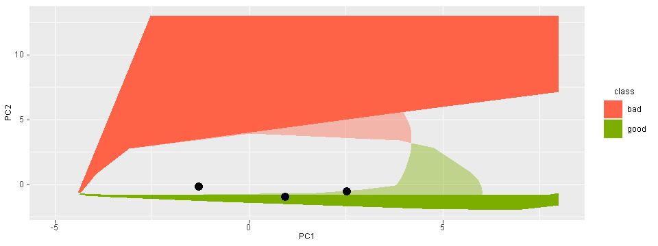

| PC1 | PC2 | good_high | bad_high | good_moderate | bad_moderate |
| --- | --- | --- | --- | --- | --- |
| 0.939510 | -0.9517519 | TRUE | FALSE | FALSE | FALSE |
| 2.533915 | -0.5280182 | FALSE | FALSE | TRUE | FALSE |
| -1.288913 | -0.1838009 | FALSE | FALSE | FALSE | FALSE |

## Evaluation

| PC1 | PC2 | good_high | bad_high | good_moderate | bad_moderate | actual |
| --- | --- | --- | --- | --- | --- | --- |
| 0.939510 | -0.9517519 | TRUE | FALSE | FALSE | FALSE | good |
| 2.533915 | -0.5280182 | FALSE | FALSE | TRUE | FALSE | good |
| -1.288913 | -0.1838009 | FALSE | FALSE | FALSE | FALSE | good |

## Discussion

Copyright (c) Berkeley Data Analytics Group, LLC Document revised August 29, 2019